# Tourism company

## Background and Context

You are a Data Scientist for a tourism company named "Visit with us". The Policy Maker of the company wants to enable and establish a viable business model to expand the customer base.

A viable business model is a central concept that helps you to understand the existing ways of doing the business and how to change the ways for the benefit of the tourism sector.

One of the ways to expand the customer base is to introduce a new offering of packages.

Currently, there are 5 types of packages the company is offering - Basic, Standard, Deluxe, Super Deluxe, King. Looking at the data of the last year, we observed that 18% of the customers purchased the packages.

However, the marketing cost was quite high because customers were contacted at random without looking at the available information.

The company is now planning to launch a new product i.e. Wellness Tourism Package. Wellness Tourism is defined as Travel that allows the traveler to maintain, enhance or kick-start a healthy lifestyle, and support or increase one's sense of well-being.

However, this time company wants to harness the available data of existing and potential customers to make the marketing expenditure more efficient.

You as a Data Scientist at "Visit with us" travel company have to analyze the customers' data and information to provide recommendations to the Policy Maker and Marketing Team and also build a model to predict the potential customer who is going to purchase the newly introduced travel package.

### Objective

To predict which customer is more likely to purchase the newly introduced travel package.

### Data Dictionary

#### Customer details:

- CustomerID: Unique customer ID
- ProdTaken: Whether the customer has purchased a package or not (0: No, 1: Yes)
- Age: Age of customer
- TypeofContact: How customer was contacted (Company Invited or Self Inquiry)
- CityTier: City tier depends on the development of a city, population, facilities, and living standards. The categories are ordered i.e. Tier 1 > Tier 2 > Tier 3
- Occupation: Occupation of customer
- Gender: Gender of customer
- PreferredPropertyStar: Preferred hotel property rating by customer
- MaritalStatus: Marital status of customer
- NumberOfTrips: Average number of trips in a year by customer
- Passport: The customer has a passport or not (0: No, 1: Yes)
- OwnCar: Whether the customers own a car or not (0: No, 1: Yes)
- NumberOfChildrenVisiting: Total number of children with age less than 5 planning to take the trip with the customer
- Designation: Designation of the customer in the current organization
- MonthlyIncome: Gross monthly income of the customer

### Customer interaction data:

- PitchSatisfactionScore: Sales pitch satisfaction score
- ProductPitched: Product pitched by the salesperson
- NumberOfFollowups: Total number of follow-ups has been done by the salesperson after the sales pitch
- DurationOfPitch: Duration of the pitch by a salesperson to the customer

### Index

- Overview of the dataset
- EDA
- Split the dataset
- Decision Tree Model
- Bagging Classifier
- Boosting Models
- Stacking Model
- Business Recommendations

## Overview of the dataset

```python
import warnings
warnings.filterwarnings("ignore")

import numpy as np
import pandas as pd
import seaborn as sns
import matplotlib.pyplot as plt
from sklearn.tree import DecisionTreeClassifier
from sklearn.ensemble import AdaBoostClassifier, GradientBoostingClassifier
from sklearn import metrics
from sklearn.model_selection import GridSearchCV, train_test_split
from sklearn.linear_model import LogisticRegression
from sklearn.metrics import accuracy_score, recall_score, precision_score, f1_score, roc_auc_score, roc_curve, confusion_matrix, precision_recall_curve
from xgboost import XGBClassifier
from sklearn.ensemble import StackingClassifier
```

```python
#Loading dataset
data_dict = pd.read_excel (r'Tourism.xlsx', sheet_name='Data Dict')# Dictory Sheet
data = pd.read_excel (r'Tourism.xlsx', sheet_name='Tourism')# Tourism Sheet
```

#### Data Dict

```python
data_dict.drop(columns=['Unnamed: 0'], inplace=True) # drop unnamed 0 col
data_dict = data_dict.rename(columns={"Unnamed: 1": "Data", "Unnamed: 2": "Variable", "Unnamed: 3": "Discerption"})
data_dict.drop(data_dict.index[0])
```

|  | Data | Variable | Discerption |
| --- | --- | --- | --- |
| 1 | Tourism | CustomerID | Unique customer ID |
| 2 | Tourism | ProdTaken | Whether the customer has purchased a package o... |
| 3 | Tourism | Age | Age of customer |
| 4 | Tourism | TypeofContact | How customer was contacted (Company Invited or... |
| 5 | Tourism | CityTier | City tier depends on the development of a city... |
| 6 | Tourism | DurationOfPitch | Duration of the pitch by a salesperson to the ... |
| 7 | Tourism | Occupation | Occupation of customer |
| 8 | Tourism | Gender | Gender of customer |
| 9 | Tourism | NumberOfPersonVisiting | Total number of persons planning to take the t... |
| 10 | Tourism | NumberOfFollowups | Total number of follow-ups has been done by sa... |
| 11 | Tourism | ProductPitched | Product pitched by the salesperson |
| 12 | Tourism | PreferredPropertyStar | Preferred hotel property rating by customer |
| 13 | Tourism | MaritalStatus | Marital status of customer |
| 14 | Tourism | NumberOfTrips | Average number of trips in a year by customer |
| 15 | Tourism | Passport | The customer has a passport or not (0: No, 1: ... |
| 16 | Tourism | PitchSatisfactionScore | Sales pitch satisfaction score |
| 17 | Tourism | OwnCar | Whether the customers own a car or not (0: No,... |
| 18 | Tourism | NumberOfChildrenVisiting | Total number of children with age less than 5 ... |
| 19 | Tourism | Designation | Designation of the customer in the current org... |
| 20 | Tourism | MonthlyIncome | Gross monthly income of the customer |

#### Tourism

```python
data.head(25)
```

|  | CustomerID | ProdTaken | Age | TypeofContact | CityTier | DurationOfPitch | Occupation | Gender | NumberOfPersonVisiting | NumberOfFollowups | ProductPitched | PreferredPropertyStar | MaritalStatus | NumberOfTrips | Passport | PitchSatisfactionScore | OwnCar | NumberOfChildrenVisiting | Designation | MonthlyIncome |
| --- | --- | --- | --- | --- | --- | --- | --- | --- | --- | --- | --- | --- | --- | --- | --- | --- | --- | --- | --- | --- |
| 0 | 200000 | 1 | 41.0 | Self Enquiry | 3 | 6.0 | Salaried | Female | 3 | 3.0 | Deluxe | 3.0 | Single | 1.0 | 1 | 2 | 1 | 0.0 | Manager | 20993.0 |
| 1 | 200001 | 0 | 49.0 | Company Invited | 1 | 14.0 | Salaried | Male | 3 | 4.0 | Deluxe | 4.0 | Divorced | 2.0 | 0 | 3 | 1 | 2.0 | Manager | 20130.0 |
| 2 | 200002 | 1 | 37.0 | Self Enquiry | 1 | 8.0 | Free Lancer | Male | 3 | 4.0 | Basic | 3.0 | Single | 7.0 | 1 | 3 | 0 | 0.0 | Executive | 17090.0 |
| 3 | 200003 | 0 | 33.0 | Company Invited | 1 | 9.0 | Salaried | Female | 2 | 3.0 | Basic | 3.0 | Divorced | 2.0 | 1 | 5 | 1 | 1.0 | Executive | 17909.0 |
| 4 | 200004 | 0 | NaN | Self Enquiry | 1 | 8.0 | Small Business | Male | 2 | 3.0 | Basic | 4.0 | Divorced | 1.0 | 0 | 5 | 1 | 0.0 | Executive | 18468.0 |
| 5 | 200005 | 0 | 32.0 | Company Invited | 1 | 8.0 | Salaried | Male | 3 | 3.0 | Basic | 3.0 | Single | 1.0 | 0 | 5 | 1 | 1.0 | Executive | 18068.0 |
| 6 | 200006 | 0 | 59.0 | Self Enquiry | 1 | 9.0 | Small Business | Female | 2 | 2.0 | Basic | 5.0 | Divorced | 5.0 | 1 | 2 | 1 | 1.0 | Executive | 17670.0 |
| 7 | 200007 | 0 | 30.0 | Self Enquiry | 1 | 30.0 | Salaried | Male | 3 | 3.0 | Basic | 3.0 | Married | 2.0 | 0 | 2 | 0 | 1.0 | Executive | 17693.0 |
| 8 | 200008 | 0 | 38.0 | Company Invited | 1 | 29.0 | Salaried | Male | 2 | 4.0 | Standard | 3.0 | Unmarried | 1.0 | 0 | 3 | 0 | 0.0 | Senior Manager | 24526.0 |
| 9 | 200009 | 0 | 36.0 | Self Enquiry | 1 | 33.0 | Small Business | Male | 3 | 3.0 | Deluxe | 3.0 | Divorced | 7.0 | 0 | 3 | 1 | 0.0 | Manager | 20237.0 |
| 10 | 200010 | 0 | 35.0 | Self Enquiry | 1 | 22.0 | Small Business | Male | 2 | 2.0 | Basic | 4.0 | Divorced | 1.0 | 0 | 3 | 1 | 1.0 | Executive | 17426.0 |
| 11 | 200011 | 0 | NaN | Self Enquiry | 1 | 21.0 | Salaried | Female | 2 | 4.0 | Deluxe | 3.0 | Single | 1.0 | 1 | 3 | 0 | 0.0 | Manager | NaN |
| 12 | 200012 | 0 | 31.0 | Self Enquiry | 1 | 32.0 | Salaried | Male | 2 | 3.0 | Basic | 3.0 | Married | 2.0 | 0 | 3 | 0 | 1.0 | Executive | 17911.0 |
| 13 | 200013 | 0 | 34.0 | Self Enquiry | 1 | 25.0 | Small Business | Male | 3 | 3.0 | Basic | 3.0 | Married | 1.0 | 0 | 3 | 0 | 2.0 | Executive | 17661.0 |
| 14 | 200014 | 1 | 28.0 | Self Enquiry | 1 | 30.0 | Salaried | Male | 2 | 4.0 | Basic | 3.0 | Single | 6.0 | 1 | 2 | 0 | 0.0 | Executive | 17028.0 |
| 15 | 200015 | 0 | 29.0 | Self Enquiry | 1 | 27.0 | Salaried | Female | 2 | 2.0 | Standard | 5.0 | Married | 2.0 | 0 | 5 | 1 | 1.0 | Senior Manager | 24980.0 |
| 16 | 200016 | 0 | 32.0 | Self Enquiry | 1 | 11.0 | Salaried | Male | 3 | 2.0 | Basic | 4.0 | Married | 1.0 | 1 | 2 | 1 | 0.0 | Executive | 18298.0 |
| 17 | 200017 | 0 | 22.0 | Company Invited | 1 | 22.0 | Small Business | Male | 3 | 2.0 | Basic | 3.0 | Married | 2.0 | 1 | 3 | 0 | 0.0 | Executive | 17935.0 |
| 18 | 200018 | 0 | 53.0 | Self Enquiry | 3 | 8.0 | Salaried | Female | 3 | 4.0 | Super Deluxe | 3.0 | Divorced | 3.0 | 0 | 3 | 1 | 0.0 | AVP | 30427.0 |
| 19 | 200019 | 0 | NaN | Self Enquiry | 1 | 8.0 | Salaried | Male | 2 | 3.0 | Basic | 3.0 | Single | 6.0 | 1 | 4 | 0 | 1.0 | Executive | NaN |
| 20 | 200020 | 0 | NaN | Company Invited | 1 | 17.0 | Salaried | Female | 3 | 2.0 | Deluxe | 3.0 | Married | 1.0 | 0 | 3 | 1 | 2.0 | Manager | NaN |
| 21 | 200021 | 1 | NaN | Self Enquiry | 3 | 15.0 | Salaried | Male | 2 | 4.0 | Deluxe | 5.0 | Single | 1.0 | 0 | 2 | 0 | 0.0 | Manager | 18407.0 |
| 22 | 200022 | 0 | 34.0 | Self Enquiry | 1 | 13.0 | Salaried | Fe Male | 2 | 3.0 | Standard | 4.0 | Unmarried | 1.0 | 0 | 3 | 1 | 0.0 | Senior Manager | 26994.0 |
| 23 | 200023 | 0 | 21.0 | Self Enquiry | 1 | 21.0 | Salaried | Male | 3 | 3.0 | Basic | 3.0 | Single | 2.0 | 0 | 3 | 1 | 1.0 | Executive | 16232.0 |
| 24 | 200024 | 1 | 34.0 | Self Enquiry | 1 | 12.0 | Small Business | Male | 2 | 3.0 | Basic | 5.0 | Single | 3.0 | 0 | 2 | 1 | 1.0 | Executive | 17960.0 |

```python
data.shape
```

```
(4888, 20)
```

**Observations-**

- There are 4888 observations and 20 columns in the dataset

**Check data types and number of non-null values for each column.**

```python
data.info()
```

```
<class 'pandas.core.frame.DataFrame'>
RangeIndex: 4888 entries, 0 to 4887
Data columns (total 20 columns):
 #   Column                    Non-Null Count  Dtype
---  ------                    --------------  -----
 0   CustomerID                4888 non-null   int64
 1   ProdTaken                 4888 non-null   int64
 2   Age                       4662 non-null   float64
 3   TypeofContact             4863 non-null   object
 4   CityTier                  4888 non-null   int64
 5   DurationOfPitch           4637 non-null   float64
 6   Occupation                4888 non-null   object
 7   Gender                    4888 non-null   object
 8   NumberOfPersonVisiting    4888 non-null   int64
 9   NumberOfFollowups         4843 non-null   float64
 10  ProductPitched            4888 non-null   object
 11  PreferredPropertyStar     4862 non-null   float64
 12  MaritalStatus             4888 non-null   object
 13  NumberOfTrips             4748 non-null   float64
 14  Passport                  4888 non-null   int64
 15  PitchSatisfactionScore    4888 non-null   int64
 16  OwnCar                    4888 non-null   int64
 17  NumberOfChildrenVisiting  4822 non-null   float64
 18  Designation               4888 non-null   object
 19  MonthlyIncome             4655 non-null   float64
dtypes: float64(7), int64(7), object(6)
memory usage: 763.9+ KB
```

**Observations-**

```python
data.isna().sum()
```

```
CustomerID                    0
ProdTaken                     0
Age                         226
TypeofContact                25
CityTier                      0
DurationOfPitch             251
Occupation                    0
Gender                        0
NumberOfPersonVisiting        0
NumberOfFollowups            45
ProductPitched                0
PreferredPropertyStar        26
MaritalStatus                 0
NumberOfTrips               140
Passport                      0
PitchSatisfactionScore        0
OwnCar                        0
NumberOfChildrenVisiting     66
Designation                   0
MonthlyIncome               233
dtype: int64
```

**Observations-**

- looks like DurationOfPitch has the highest count of missing data at 251
- Looks like TypeofContact has the lowest count of missing data at 25

```python
data[data.duplicated()].count()
```

```
CustomerID                  0
ProdTaken                   0
Age                         0
TypeofContact               0
CityTier                    0
DurationOfPitch             0
Occupation                  0
Gender                      0
NumberOfPersonVisiting      0
NumberOfFollowups           0
ProductPitched              0
PreferredPropertyStar       0
MaritalStatus               0
NumberOfTrips               0
Passport                    0
PitchSatisfactionScore      0
OwnCar                      0
NumberOfChildrenVisiting    0
Designation                 0
MonthlyIncome               0
dtype: int64
```

**Observations-**

- No duplicated data

**Number of unique values in each column**

```python
data.nunique()
```

```
CustomerID                  4888
ProdTaken                      2
Age                           44
TypeofContact                  2
CityTier                       3
DurationOfPitch               34
Occupation                     4
Gender                         3
NumberOfPersonVisiting         5
NumberOfFollowups              6
ProductPitched                 5
PreferredPropertyStar          3
MaritalStatus                  4
NumberOfTrips                 12
Passport                       2
PitchSatisfactionScore         5
OwnCar                         2
NumberOfChildrenVisiting       4
Designation                    5
MonthlyIncome               2475
dtype: int64
```

**Observations-**

- CustomerID at 4888 and MonthlyIncome at 2475 have the highest number of unique values in each column.

**Summary of the dataset**

```python
data.describe().T
```

|  | count | mean | std | min | 25% | 50% | 75% | max |
| --- | --- | --- | --- | --- | --- | --- | --- | --- |
| CustomerID | 4888.0 | 202443.500000 | 1411.188388 | 200000.0 | 201221.75 | 202443.5 | 203665.25 | 204887.0 |
| ProdTaken | 4888.0 | 0.188216 | 0.390925 | 0.0 | 0.00 | 0.0 | 0.00 | 1.0 |
| Age | 4662.0 | 37.622265 | 9.316387 | 18.0 | 31.00 | 36.0 | 44.00 | 61.0 |
| CityTier | 4888.0 | 1.654255 | 0.916583 | 1.0 | 1.00 | 1.0 | 3.00 | 3.0 |
| DurationOfPitch | 4637.0 | 15.490835 | 8.519643 | 5.0 | 9.00 | 13.0 | 20.00 | 127.0 |
| NumberOfPersonVisiting | 4888.0 | 2.905074 | 0.724891 | 1.0 | 2.00 | 3.0 | 3.00 | 5.0 |
| NumberOfFollowups | 4843.0 | 3.708445 | 1.002509 | 1.0 | 3.00 | 4.0 | 4.00 | 6.0 |
| PreferredPropertyStar | 4862.0 | 3.581037 | 0.798009 | 3.0 | 3.00 | 3.0 | 4.00 | 5.0 |
| NumberOfTrips | 4748.0 | 3.236521 | 1.849019 | 1.0 | 2.00 | 3.0 | 4.00 | 22.0 |
| Passport | 4888.0 | 0.290917 | 0.454232 | 0.0 | 0.00 | 0.0 | 1.00 | 1.0 |
| PitchSatisfactionScore | 4888.0 | 3.078151 | 1.365792 | 1.0 | 2.00 | 3.0 | 4.00 | 5.0 |
| OwnCar | 4888.0 | 0.620295 | 0.485363 | 0.0 | 0.00 | 1.0 | 1.00 | 1.0 |
| NumberOfChildrenVisiting | 4822.0 | 1.187267 | 0.857861 | 0.0 | 1.00 | 1.0 | 2.00 | 3.0 |
| MonthlyIncome | 4655.0 | 23619.853491 | 5380.698361 | 1000.0 | 20346.00 | 22347.0 | 25571.00 | 98678.0 |

**Observations-**

**Number of observations in each category**

```python
cat_cols=['Age',
          'TypeofContact',
          'DurationOfPitch',
          'Occupation',
          'Gender',
          'NumberOfFollowups',
          'ProductPitched',
          'MaritalStatus',
          'PreferredPropertyStar',
          'NumberOfTrips',
          'NumberOfChildrenVisiting' ,
          'Designation',
          'MonthlyIncome']

for column in cat_cols:
    print(data[column].value_counts())
    print('-'*30)
```

```
35.0    237
36.0    231
34.0    211
31.0    203
30.0    199
32.0    197
33.0    189
37.0    185
29.0    178
38.0    176
41.0    155
39.0    150
28.0    147
40.0    146
42.0    142
27.0    138
43.0    130
46.0    121
45.0    116
26.0    106
44.0    105
51.0     90
47.0     88
50.0     86
25.0     74
52.0     68
53.0     66
48.0     65
49.0     65
55.0     64
54.0     61
56.0     58
24.0     56
22.0     46
23.0     46
59.0     44
21.0     41
20.0     38
19.0     32
58.0     31
```

[output cut: 108 more lines]

```
Name: Designation, dtype: int64
------------------------------
21020.0    7
20855.0    7
17342.0    7
21288.0    7
17741.0    6
          ..
24924.0    1
19507.0    1
21108.0    1
20953.0    1
1000.0     1
Name: MonthlyIncome, Length: 2475, dtype: int64
------------------------------
```

**Observations-**

**Dropping column**

```python
data.drop(columns=['CustomerID'], inplace=True)
```

## EDA

### Univariate analysis

```python
def histogram_boxplot(feature, figsize=(15,10), bins = None):
    """ Boxplot and histogram combined
    feature: 1-d feature array
    figsize: size of fig (default (9,8))
    bins: number of bins (default None / auto)
    """
    f2, (ax_box2, ax_hist2) = plt.subplots(nrows = 2, # Number of rows of the subplot grid= 2
                                           sharex = True, # x-axis will be shared among all subplots
                                           gridspec_kw = {"height_ratios": (.25, .75)},
                                           figsize = figsize
                                           ) # creating the 2 subplots
    sns.boxplot(feature, ax=ax_box2, showmeans=True, color='violet') # boxplot will be created and a star will indicate the mean value of the column
    sns.distplot(feature, kde=F, ax=ax_hist2, bins=bins,palette="winter") if bins else sns.distplot(feature, kde=False, ax=ax_hist2) # For histogram
    ax_hist2.axvline(np.mean(feature), color='green', linestyle='--') # Add mean to the histogram
    ax_hist2.axvline(np.median(feature), color='black', linestyle='-') # Add median to the histogram
```

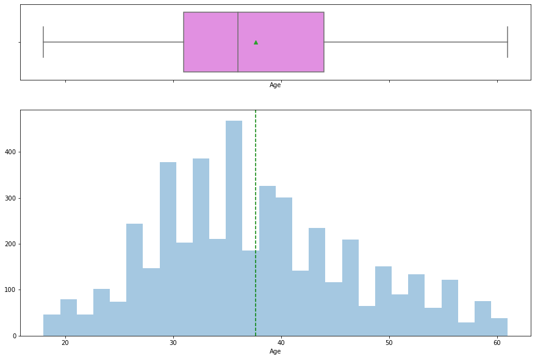

```python
histogram_boxplot(data['Age'])
```

- The distribution is nearly symmetric with no outliers to the right or left.
- The mean and median values are almost the same
- The mean and median are at 37 for age

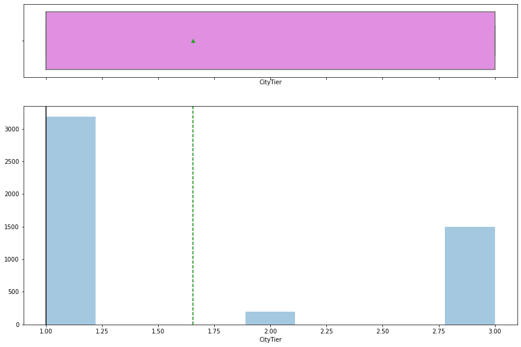

```python
histogram_boxplot(data['CityTier'])
```

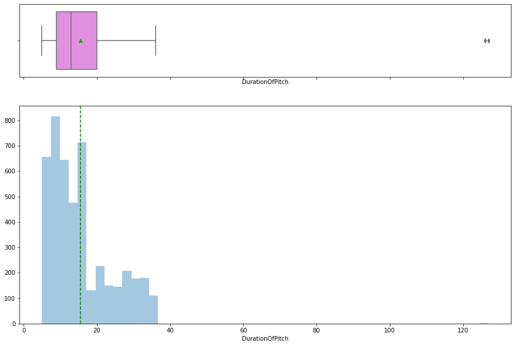

```python
histogram_boxplot(data['DurationOfPitch'])
```

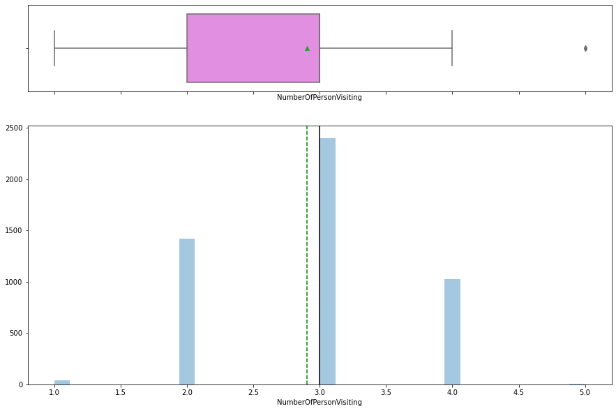

```python
histogram_boxplot(data['NumberOfPersonVisiting'])
```

- The averge amount of people visiting is 3.
- There is outliers to the right
- The distribution is nearly symmetric

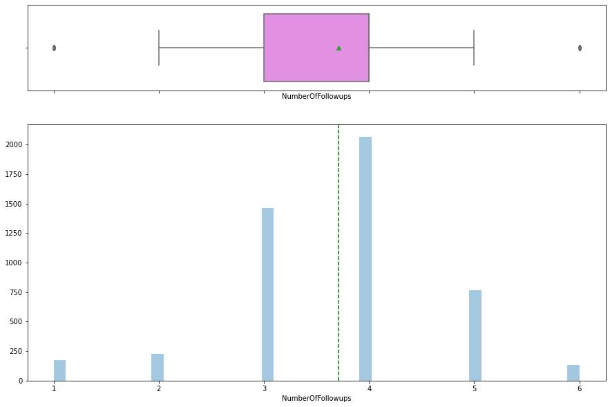

```python
histogram_boxplot(data['NumberOfFollowups'])
```

- The distribution is nearly symmetric with some outliers on both sides.
- The mean and median values are close to 3.8 for NumberOfFollowups

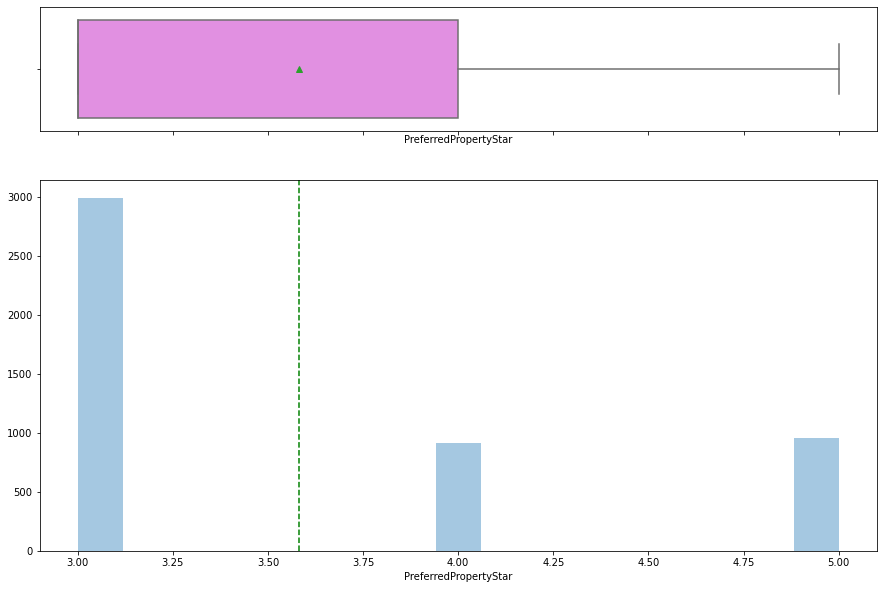

```python
histogram_boxplot(data['PreferredPropertyStar'])
```

- The distribution is not symmetric and is skewed
- The averge rating is 3.55

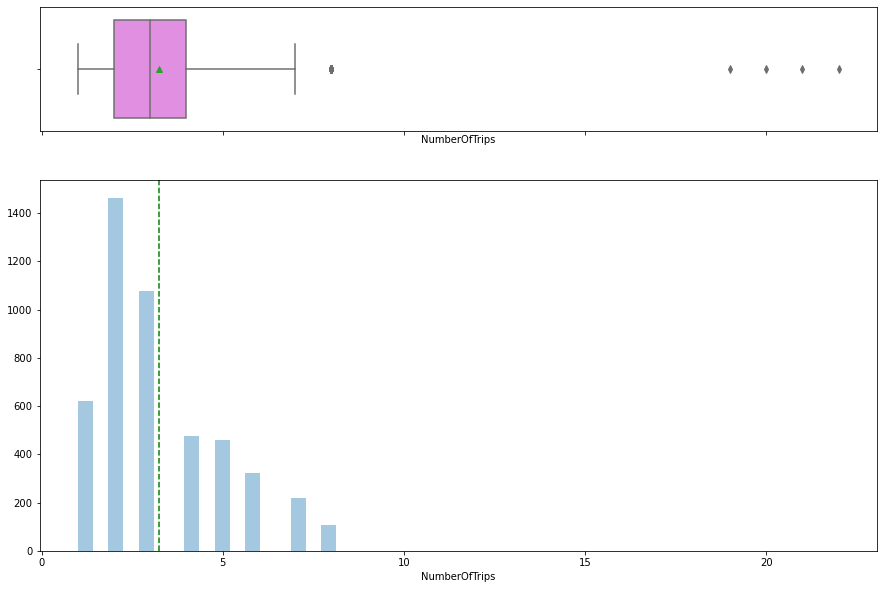

```python
histogram_boxplot(data['NumberOfTrips'])
```

- The distribution is not symmetric with outliers to the right as well as a skew.
- The outliers present to the right indicate that some people needed more visits then other before they made the purchase

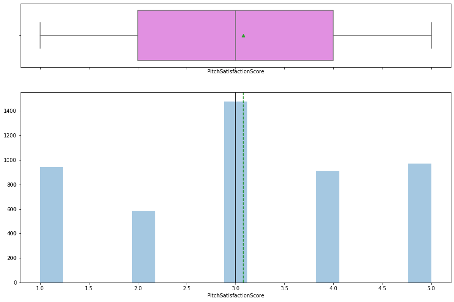

```python
histogram_boxplot(data['PitchSatisfactionScore'])
```

- The distribution is nearly symmetric with no outliers.
- The mean and median values are close to 3.0 for PitchSatisfactionScore.

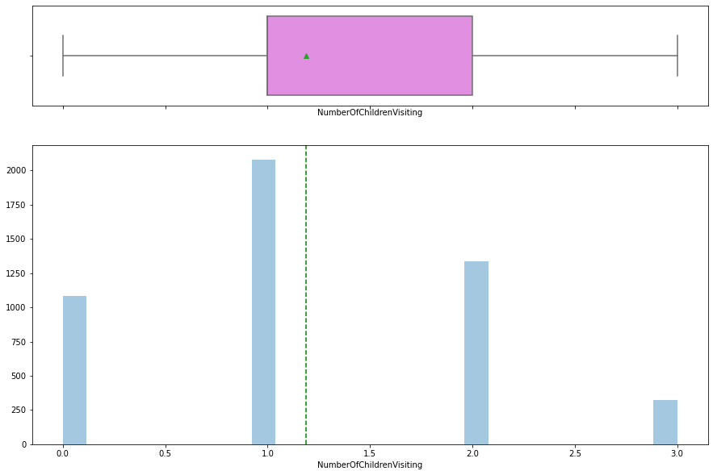

```python
histogram_boxplot(data['NumberOfChildrenVisiting'])
```

- This is a odd colume that is highly correlated to NumberOfPersonVisiting and should be drop.
- The averge amount of children persent at the meeting is about 1.25

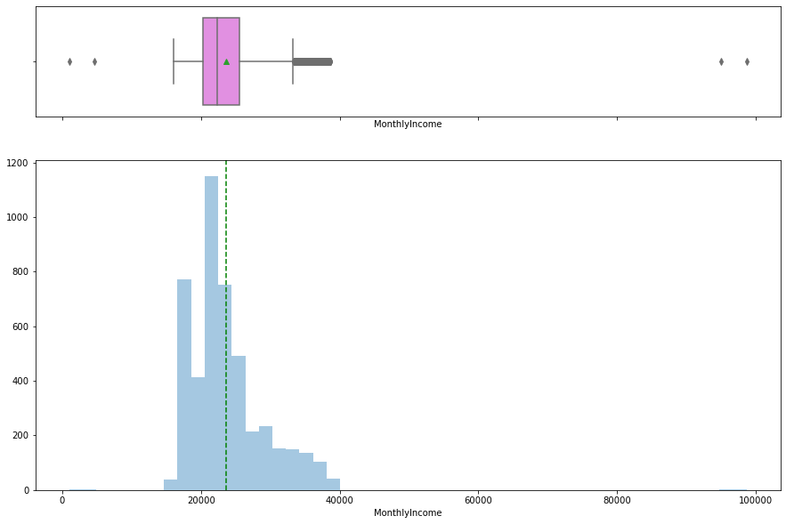

```python
histogram_boxplot(data['MonthlyIncome'])
```

- The distribution is not symmetric with outliers on both sides.
- The mean and median values are not close
- The outliers present to the right indicate some buyers make way more money then other
- it is odd to see that thier are potential buyers that have a very low income which is close to 0.

**Function to create barplots that indicate percentage for each category**

```python
def perc_on_bar(feature):
    '''
    plot
    feature: categorical feature
    the function won't work if a column is passed in hue parameter
    '''
    #Creating a countplot for the feature
    sns.set(rc={'figure.figsize':(15,7)})
    ax=sns.countplot(x=feature, data=data)

    total = len(feature) # length of the column
    for p in ax.patches:
        percentage = '{:.1f}%'.format(100 * p.get_height()/total) # percentage of each class of the category
        x = p.get_x() + p.get_width() / 2 - 0.25 # width of the plot
        y = p.get_y() + p.get_height()           # hieght of the plot
        ax.annotate(percentage, (x, y), size = 14) # annotate the percantage

    plt.show() # show the plot
```

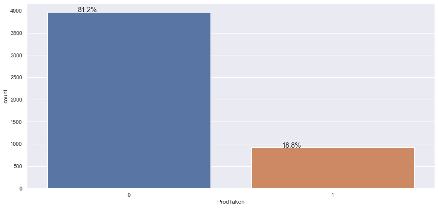

```python
perc_on_bar(data['ProdTaken'])
```

- About 81% did not purchase a package and 19% percent did
- This is a strong indication that either the sales pitch apporch is not working or the sales repersenitive is not trianed well enough.

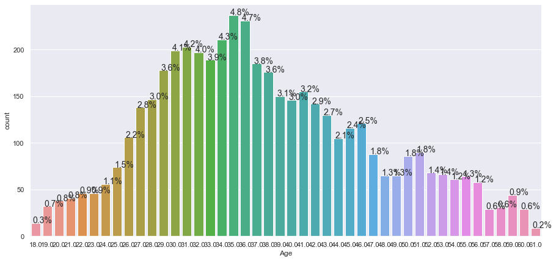

```python
perc_on_bar(data['Age'])
```

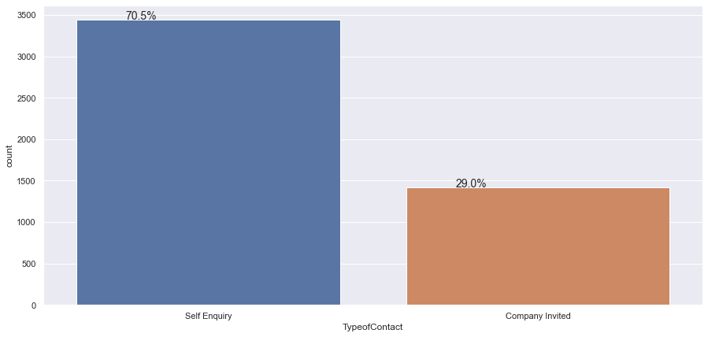

```python
perc_on_bar(data['TypeofContact'])
```

- About 70% of the buyers did by self enquiry

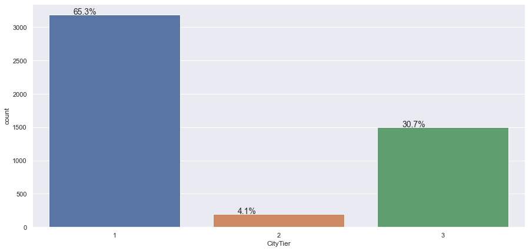

```python
perc_on_bar(data['CityTier'])
```

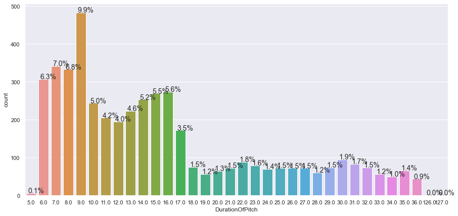

```python
perc_on_bar(data['DurationOfPitch'])
```

- About 9.9% had a sale pitch that last 9 min

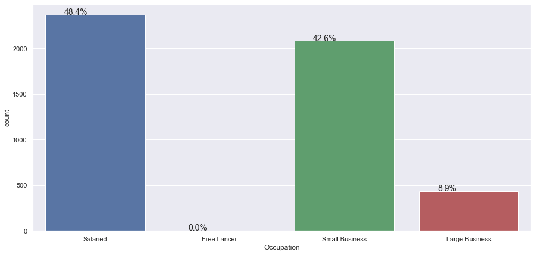

```python
perc_on_bar(data['Occupation'])
```

The occupation of the potential buyers is mostly divided between salaried and small business

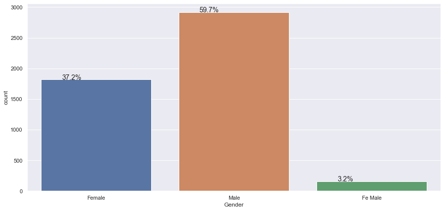

```python
perc_on_bar(data['Gender'])
```

- About 60% are male
- About 37% are female
- We have to look into Fe male to see if it is a error or not

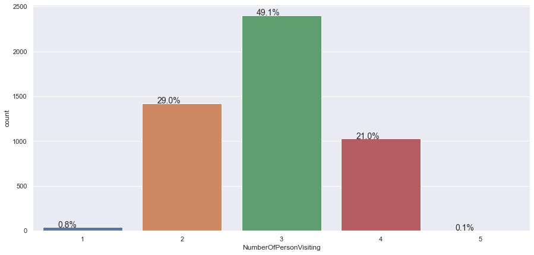

```python
perc_on_bar(data['NumberOfPersonVisiting'])
```

- three seem to be the most common number of person visiting

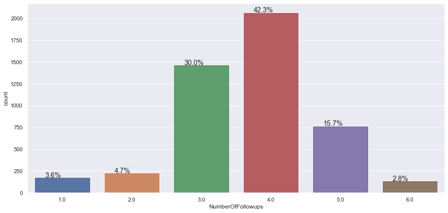

```python
perc_on_bar(data['NumberOfFollowups'])
```

It looks like it takes a minium of 3 to 5 follow ups to procure a sale

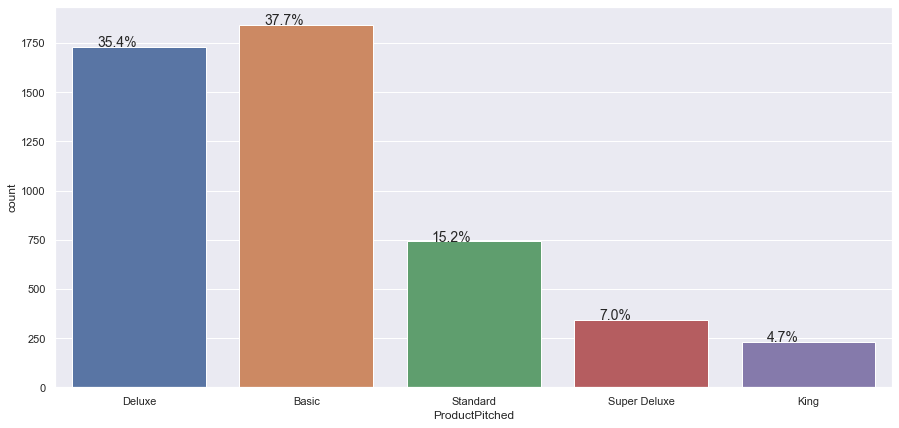

```python
perc_on_bar(data['ProductPitched'])
```

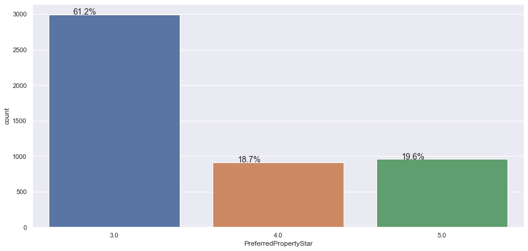

```python
perc_on_bar(data['PreferredPropertyStar'])
```

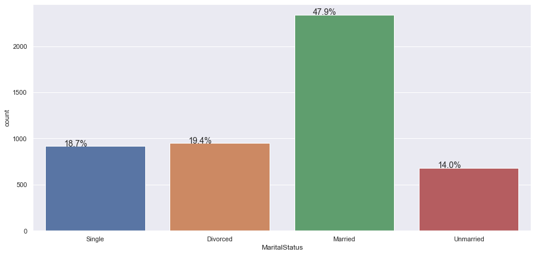

```python
perc_on_bar(data['MaritalStatus'])
```

About 47.9% are married and the rest is almost evenly spilt between the other three

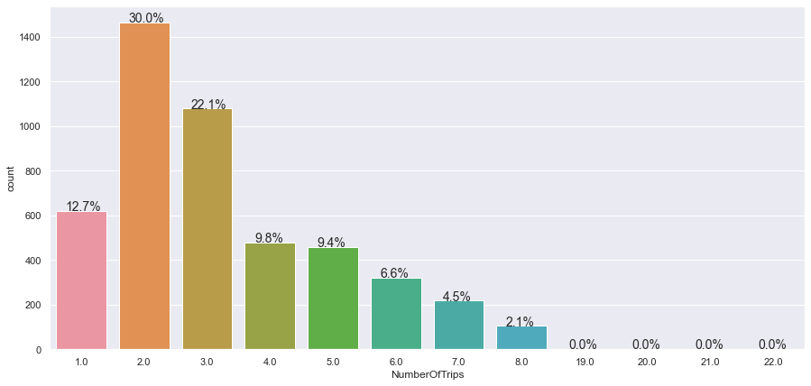

```python
perc_on_bar(data['NumberOfTrips'])
```

It looks like it takes a minium of 2 to 3 trips to procure a sale

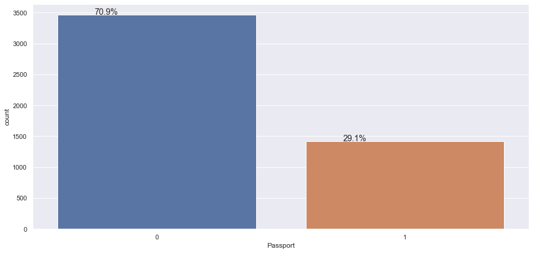

```python
perc_on_bar(data['Passport'])
```

Most people dont have passport and only about 30% do

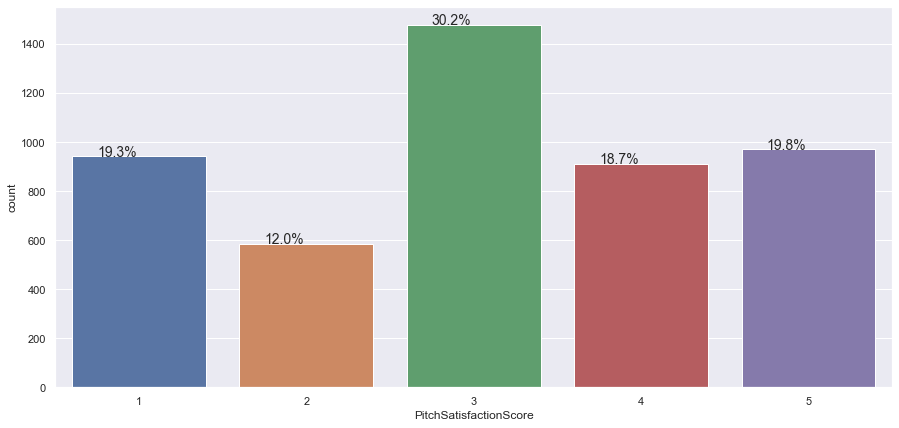

```python
perc_on_bar(data['PitchSatisfactionScore'])
```

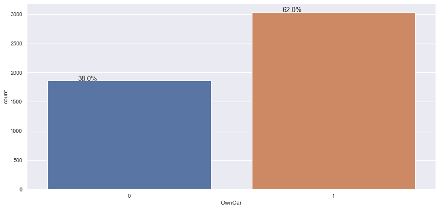

```python
perc_on_bar(data['OwnCar'])
```

About 60% own aleast one car

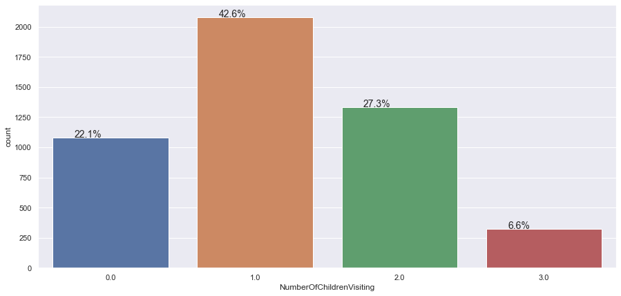

```python
perc_on_bar(data['NumberOfChildrenVisiting'])
```

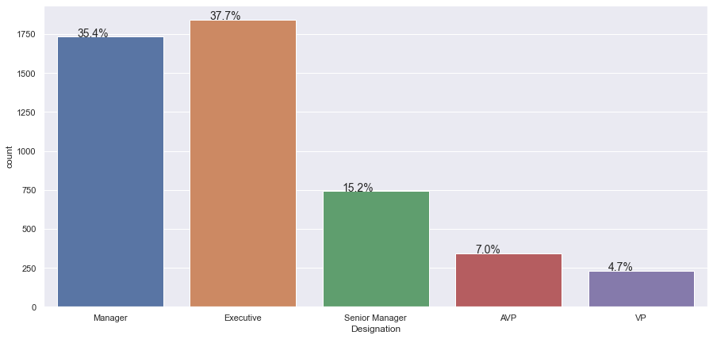

```python
perc_on_bar(data['Designation'])
```

Manages and Exectives make up about 75% of the sales